# Mokelumne River

Mark Tompkins

July 2024

## Instream Spawning and Rearing Habitat

**Data Source:** LMR_HSI_2015conditions.xlsx

Data was provided by East Bay Municipal Utility District for Fall Run HSI-Flow relationships for Chinook Salmon. The data represents pre-2018 early implementation conditions. The suitability criteria (Table 1) used is the same as that applied for the Health Rivers and Landscapes program Mokelumne River assessment.

Table 1. Habitat suitability indices (HSI) applied to spawning, in channel rearing, and floodplain rearing to get the total suitable habitat area relationships

|  | Spawning | Instream Rearing | Floodplain Rearing |
| --- | --- | --- | --- |
| Depth (feet) | 1.0 - 2.5 | 0.5 - 4.0 | 0.5 - 4.0 |
| Velocity (feet/s) | 1.0 - 4.0 | 0.0 - 3.0 | 0.0 - 3.0 |

### Combine Instream Spawning and Rearing Habitat Data

**Notes**

- Fry and Juvenile Instream rearing currently have the same value because the same HSI was applied in the modeling efforts
- Steelhead spawning is the same as Fall Run since the older data is in WUA format

Header Descriptions: flow_cfs = flow in cubic feet per second, FR_spawn_sqm = Fall Run Chinook Spawning (square meters), FR_fry_sqm = Fall Run Chinook Fry (square meters), FR_juv_sqm = Fall Run Chinook Juvenile (square meters), ST_spawn_sqm = Steelhead Spawning (square meters), watershed = section of stream modeled for Reorienting to Recovery reach

| flow_cfs | FR_spawn_sqm | FR_fry_sqm | FR_juv_sqm | ST_spawn_sqm | watershed |
| --- | --- | --- | --- | --- | --- |
| 100 | 31875.91 | 314972.2 | 314972.2 | 31875.91 | Mokelumne River |
| 200 | 63714.68 | 335038.9 | 335038.9 | 63714.68 | Mokelumne River |
| 400 | 77956.76 | 328618.2 | 328618.2 | 77956.76 | Mokelumne River |
| 600 | 63614.70 | 272077.4 | 272077.4 | 63614.70 | Mokelumne River |
| 800 | 39085.03 | 205899.3 | 205899.3 | 39085.03 | Mokelumne River |

*… with 11 more rows*

### Spawning Habitat Area

The following plot shows the weighted usable spawning area in acres for Fall Run Chinook Salmon (FR) and Steelhead.

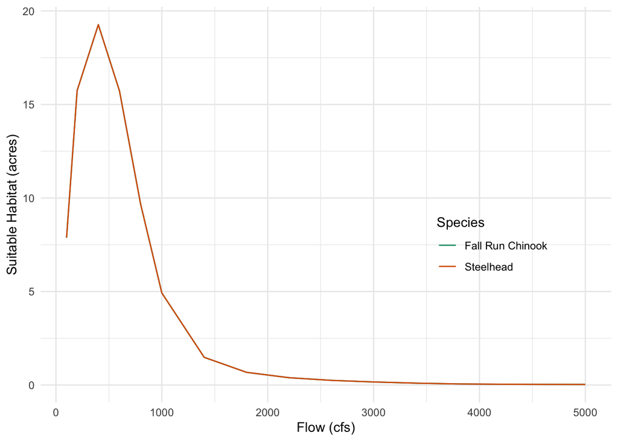

### Rearing Habitat Area

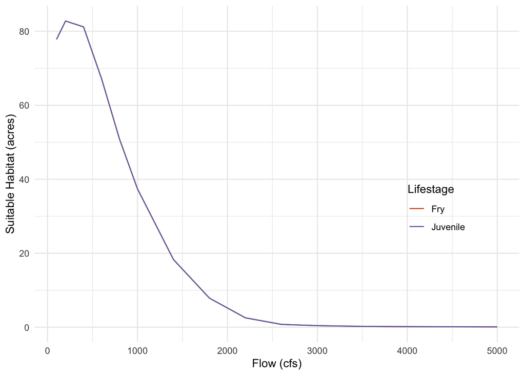

## Floodplain Rearing Habitat

Juvenile floodplain criteria is shown in Table 1.

**Data Source:** LMR_HSI_2015conditions.xlsx, sheet: Juvenile-floodplain

**Notes**

- Fall Run, Spring Run, and Steelhead use the same floodplain rearing habitat to flow relationship. This methodology is consistent with how Mokelumne River floodplain rearing habitat as modeled in CVPIA DSMhabitat.

Header Descriptions: flow_cfs = flow in cubic feet per second, FR_floodplain_acres = Fall Run Chinook floodplain acres, SR_floodplain_acres = Spring Run Chinook floodplain acres, ST_floodplain_acres = Steelhead floodplain acres, watershed = section of stream modeled for Reorienting to Recovery reach

| flow_cfs | FR_floodplain_acres | SR_floodplain_acres | ST_floodplain_acres | watershed |
| --- | --- | --- | --- | --- |
| 100 | 1.68 | 1.68 | 1.68 | Mokelumne River |
| 200 | 2.38 | 2.38 | 2.38 | Mokelumne River |
| 400 | 3.99 | 3.99 | 3.99 | Mokelumne River |
| 600 | 11.56 | 11.56 | 11.56 | Mokelumne River |
| 800 | 20.66 | 20.66 | 20.66 | Mokelumne River |

*… with 11 more rows*

## Floodplain Plot

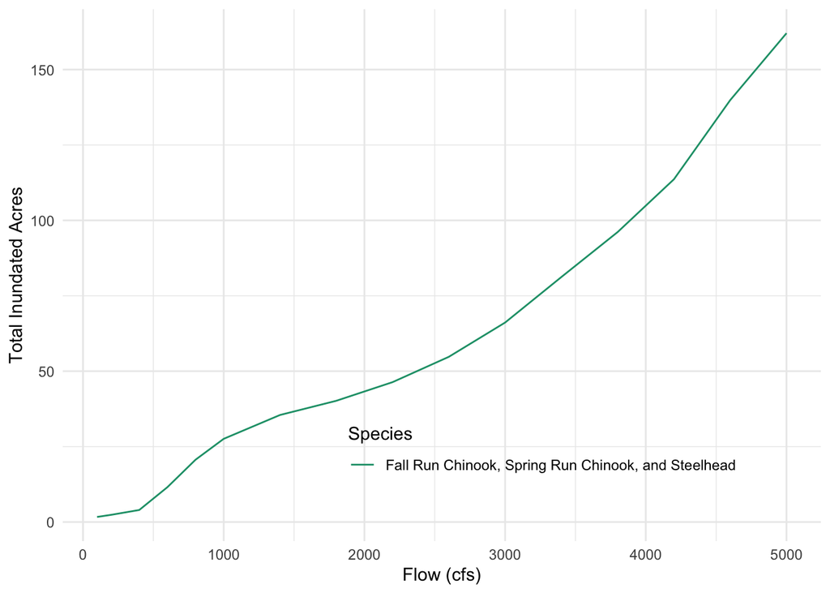